# Complex Survey Notes

Adam Peterson

2024-04-14

# Preface

What follows is a coded work through of Thomas Lumley’s “Complex Surveys: A Guide to Analysis in R” (Lumley 2011). These documents will reflect my understanding of the material with additions made to try and clarify ideas further. These include simulations, derivations or references that I found helpful in working through Lumley’s material. Most of the datasets that I use throughout these notes are from Lumley’s website for the [book](https://r-survey.r-forge.r-project.org/survey/). However, I’ll also create my own simulated datasets so that it can be understood both how to analyze data that have been sampled as described in this book, as well as how to perform the sampling and construct the inclusion probabilities / sampling weights. This latter half is not elaborated on to the same extent in this text but I think it is just as important in an applied context.

# Chapter 1: The Basics

## Design vs. Model

Key to analysis of complex surveys is the idea of studying the design from which the data are constructed, rather than the data itself. That is to say, that in a traditional survey setting the data are assumed to be fixed and the probabilities of sampling different entities are used to derive the desired estimate. These “weights” are used to re-balance the data so that they more accurately reflect the target population distribution. Different sampling techniques — clustering, 2-phase, etc. — are used to either decrease the variance of the resulting estimate *or* decrease the cost associated with the design or both.

### Horvitz Thompson Estimation

The Horvitz Thompson Estimator (HTE) is the starting point for non-uniform random estimates. If we observe measure $X_i$ on subject $i$ of a population of $N$ total subjects the HTE is formulated as follows:

$$HTE(X) = \sum_{i=1}^{N} \frac{1}{\pi_i}X_i,$$

which is an unbiased estimator as shown in the Chapter 1 Appendix.

The variance of this estimate is then

$$V[HTE(X)] = \sum_{i,j} \left ( \frac{X_i X_j}{\pi_{ij}} -
\frac{X_i}{\pi_i} \frac{X_j}{\pi_j} \right ),$$

which follows from the Bernoulli covariance using indicator variables $R_i=1$ if individual $i$ is in the sample, $R_i=0$ otherwise. A proof is provided in the Questions From Chapter 1.

### Design And Misspecification Effects

(Kish 1965) defined the notion of a *design effect* as the ratio of a variance of an estimate in a complex sample to the variance of the same estimate in a simple random sample (SRS). The motivation for this entity being that it can guide researchers in terms of how much sample size they may need; If the sample size for a given level of precision is known for a simple random sample, the sample size for a complex design can be obtained by multiplying by the design effect.

While larger sample sizes may be more necessary to maintain the same level of variance as a SRS, the more complex may still be more justified because of the lower cost associated. See (Meng 2018) for an example of where design effects are used in a modern statistical setting.

The misspecification effect is the ratio of the the variance of a correct estimate to the incorrect variance from the result of a SRS. This value is used less in the modern era, but may still be worth knowing.

## Questions From Chapter 1

1.1-1.2 Don’t make sense to reproduce here.

1.3 Each visit to the front page of a newspaper’s website has (independently) a 1/1000 chance of resulting in a questionnaire on voting intentions in a forthcoming election. Assuming that everyone who is given the questionnaire responds, why are the results not a probability sample of

- Voters?
- Readers of the newspaper?
- Readers of the newspaper’s online version?

Lumley lists 4 properties needed for a sample to be considered a probability sample.

1. Every individual (unit of analysis) in the population must have a non-zero probability of ending up in the sample ($\pi_i>0 \forall i$)
2. $\pi_i$ must be known for every individual who does end up in the sample.
3. Every pair of individuals in the sample must have a non-zero probability of both ending up in the sample ($\pi_{i,j} \forall i, j$)
4. The probability $\pi_{i,j}$ must be known for every pair that does end up in the sample.

1 is not guaranteed when considering voters — there are voters who don’t read the paper who have will have $\pi_i = 0$ — or the broader heading of “readers” of the newspaper - since those who only read the physical paper will have a $_i = 0 $. For “readers of the newspaper’s online version” the sample would only be a probability sample if the time window was further specified, as there could be online readers who do not visit during the survey window, and would thus be assigned a $\pi_i=0$.

1.4 You are conducting a survey that will estimate the proportion of women who used anti-malarial insecticide-treated bed nets every night during their last pregnancy. With a simple random sample you would need to recruit 50 women in any sub-population where you wanted a standard error of less than 5 percentage points in the estimate. You are using a sampling design that has given design effects of 2-3 for proportions in previous studies in similar areas.

- Will you need a larger or smaller sample size than 50 for a subpopulation to get the desired precision?

Larger, a design effect $>1$ indicates that the variance is larger in the complex design with the same sample size - consequently the sample size will need to be increased to maintain the same level of precision.

- Approximately what sample size will you need to get the desired precision?

100 - 150. Derived from multiplying 50 by 2 and 3.

1.5 Systematic sampling involves taking a list of the population and choosing, for example, every 100th entry in the list.

1. Which of the necessary properties of a probability sample does this have?

Items 2-4 from the list enumerated above. The only condition that is not satisfied is that not every item has a nonzero probability of being chosen.

2. For systematic sampling with a random start, the procedure would be to choose a random starting point from 1, 2, …, 1000 and then take every 100th entry starting at the random point. Which of the necessary properties of a probability sample does this procedure have?

This satisfies all items from the above list.

3. For systematic sampling with multiple random starts we might choose 5 random starting points in 1, 2, ….., 5000 and then take every 500th entry starting from each of the 5 random points. Which of the necessary properties of a probability sample does this procedure have?

Again, this satisfies all items from the above list.

4. If the list were shuffled into a random order before a systematic sample was taken, which of the properties would the procedure have.

Again, all of them. The key is adding the *known* randomness and not excluding any items from selection.

5. Treating a systematic sample as if it were a simple random sample often gives good results. Why would this be true?

This would be because the items are not ordered in any particular fashion prior to taking the “systematic sampling”. In this setting a systematic sample is equivalent to a simple random sample.

1.6 Why must all the sampling probabilities be non-zero to get a valid population estimate?

If any of the sampling probabilities are zero, that would introduce bias in shifting the estimate away from the *always* unobserved portion of the population.

1.7 Why must all the pairwise probabilities be non-zero to get a valid uncertainty estimate.

This is basically a second order statement equivalent to the previous. If any pair is unable to be observed together that is a form of selection bias that would shift the population estimate away from the true value.

1.8 A probability design assumes that people who are sampled will actually be included in the sample, rather than refusing. Look up the response rates for the most recent year of BRFSS and NHANES.

1.9 In a telephone study using random digit dialing, telephone numbers are sampled with equal probability from a list. When a household is recruited, why is it necessary to ask how many telephones are in the household, and what should be done with this information in computing the weights.

It is necessary to ask how many telephones are in the household to downweight the *a priori* sampling probability accordingly because every additional telephone line increases the odds that a given house is sampled. For example in a simple population with two houses, where house one has 5 telephones and house two has 2 telephones, and we’re looking to take a $n=1$ sample, but we don’t know the number of telephones a priori, house one has a $\frac{5}{7}$ probability of being sampled. If that is the house that is chosen its weight needs to go from 2 to $\frac{5}{7}$ to better reflect its sampling probability. In a real sample this would be corrected relative to all the other households number of telephones or perhaps a population average of the number of telephones.

1.10

Derive the Horvitz Thompson variance estimator for the total as follows.

1. Write $R_i = 1$ if individual $i$ is in the sample, $R_i=0$ otherwise. Show that $V[R_i] = \pi_i(1-\pi_i)$ and that $Cov[R_i,R_j]=\pi_{ij} - \pi_i\pi_j$.

This follows in a straightforward fashion assumign that $R_i$ is distributed according to the binomial distribution. This is an accurate model for sampling with replacement, or sampling from large populations with small sample sizes without replacement, but less true for small sample sizes without replacement.

2. Show that the variance of the Horvitz Thompson estimator is:

$$V[\hat{T}_{HT}] = \sum_{i=1}^{N}\sum_{j=1}^{N}
\check{x}_i\check{x}_j(\pi_{ij} - \pi_i \pi_j)$$
We have,
$$HTE:= \sum_{i=1}^{N} \frac{X_i I(X_i \in \mathcal{S})}{\pi_i} \\
V[HTE] = V\left[\sum_{i=1}^{N}\frac{X_i I(X_i \in \mathcal{S})}{\pi_i}
\right] \\
=\sum_{i=1}^{N}\sum_{j=1}^{N} Cov\left[\frac{X_i I(i \in
\mathcal{S})}{\pi_i},
\frac{X_j I(j \in \mathcal{S})}{\pi_j}\right]\\
= \sum_{i=1}^{N}\sum_{j=1}^{N} \frac{X_i}{\pi_i}\frac{X_j}{\pi_j}Cov(I(i
\in
\mathcal{S}),I(j \in \mathcal{S})) \\
= \sum_{i=1}^{N}\sum_{j=1}^{N} \frac{X_i}{\pi_i}\frac{X_j}{\pi_j}
(\pi_{ij} -
\pi_i \pi_j)$$

which is equivalent to the above, where $\check{x_i} = \frac{X_i}{\pi_i}$.

3. Show that an unbiased estimator of the variance is
   $$\hat{V}[\hat{T}_{HT}] = \sum_{i=1}^{N}\sum_{j=1}^{N}
   \frac{R_i R_j}{\pi_{ij}}\check{x_i}\check{x_j}(\pi_{ij} - \pi_i \pi_j)$$
4. Show that the previous expression simplifies to equation 1.2

1.11 Another popular way to write the Horvitz-Thompson variance estimator is

$$\hat{V}[\hat{T}_{HT}] = \sum_{i=1}^{n} x_i^{2} \frac{1-\pi_i}{\pi_i^2} +
\sum_{i\neq j}x_ix_j\frac{\pi_{ij} - \pi_i \pi_j}{\pi_i\pi_j\pi_{ij}}$$

## Chapter 1 Appendix

The HTE is an unbiased estimator of the population total - I reproduce the expression from above, but now make explicit the indicator variables that express which observations are included in our sample, $\mathcal{S}$.

$$HTE := \sum_{i=1}^{N} \frac{X_i I(X_i \in \mathcal{S})}{\pi_i} \\
E[HTE] = E\left [\sum_n \frac{X_i I(X_i \in \mathcal{S})}{\pi_i} \right
] \\
= \sum_n E \left [\frac{X_iI(X_i \in \mathcal{S})}{\pi_i} \right ] \\
= \sum_n \frac{X_iE[I(X_i \in \mathcal{S})]}{\pi_i} \\
= \sum_n \frac{X_i \pi_i}{\pi_i} = \sum_n X_i$$

# Chapter 2: Simple and Stratified Sampling

## Starting from Simple Random Samples

When dealing with *a sample* of size $n$ from a population of size $N$ the HTE of the total value of $X_i$ in the population can be written as

$$\begin{equation}
HTE(X) = \hat{T_X} = \sum_{i=1}^{n} \frac{X_i}{\pi_i}.
\end{equation}$$

For a simple random sample, the variance can be more explicitly written as

$$\begin{equation}
V[\hat{T_X}] = \frac{N-n}{N} \times N^{2} \times \frac{V[X]}{n},
\end{equation}$$

where $\frac{N-n}{N}$ is the finite population correction factor. This factor is [derived](https://stats.stackexchange.com/questions/5158/explanation-of-finite-population-correction-factor) from the hypergeometric distribution and explains the reduction in uncertainty that follows from sampling a large portion of the population. Consequently, if the sample is taken with replacement — the same individual or unit has the possibility to be sampled twice — this term is no longer relevant. It should be noted that sampling with replacement is not usually used however, but sometimes this language is used to refer to the fact that the finite correction factor may not be used.

The second term, $N^2$, rescales the estimate from the mean to the total, while the final term is simply the scaled variance of $X$.

A point worth deliberating on, that Lumley notes as well, is that while the above equations suggest that a larger sample size is always better that is not always the case in reality. Non-response bias or the cost of surveys can dramatically diminish the *quality* of the dataset, even if the size is large. I state this is worth deliberating on because it is a matter of increasing importance in the world of “Big Data” - where it can be easy to delude oneself with confidence in their estimates because their sample is large, even when the sample is not well designed. See (Meng 2018) for a larger discussion of this topic.

It follows from the above that the HTE for the population size is defined as $\hat{N} = \sum_{i=1}^{n} \frac{1}{\pi_i}$. This holds true in the case where, as here $\pi_i = \frac{n}{N}$, a bit trivial, but also in those where $\pi_i$ may be defined differently.

## Confidence Intervals

The sampling distribution for the estimates — typically sample means and sums — across “repeated surveys” is Normal by the Central Limit Theorem, so the typical $\bar{x} \pm 1.96 \sqrt{\frac{\sigma^2_X}{n}}$, expression is used to calculate a 95% confidence interval. Lumley offers the following example from the California Academic Performance Index (API) [dataset](https://www.cde.ca.gov/re/pr/api.asp) to illustrate this idea.

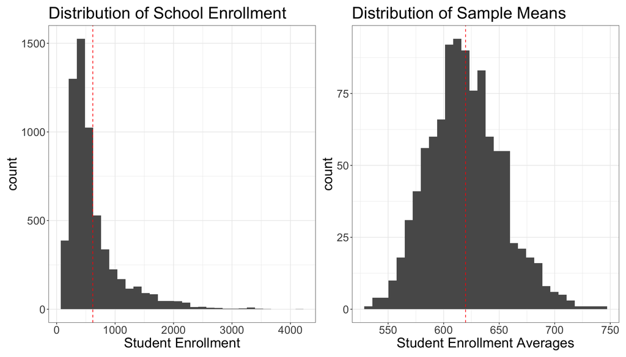

```r
data(api)
mn_enroll <- mean(apipop$enroll, na.rm = TRUE)
p1 <- apipop %>%
  ggplot(aes(x = enroll)) +
  geom_histogram() +
  xlab("Student Enrollment") +
  geom_vline(xintercept = mn_enroll, linetype = 2, color = "red") +
  ggtitle("Distribution of School Enrollment")
p2 <- replicate(n = 1000, {
  apipop %>%
    sample_n(200) %>%
    pull(enroll) %>%
    mean(., na.rm = TRUE)
})
mn_sample_mn <- mean(p2)
p2 <- tibble(sample_ix = 1:1000, sample_mean = p2) %>%
  ggplot(aes(x = sample_mean)) +
  geom_histogram() +
  xlab("Student Enrollment Averages") +
  geom_vline(
    xintercept = mn_sample_mn,
    linetype = 2, color = "red"
  ) +
  ggtitle("Distribution of Sample Means")
p1 + p2
```

## Complex Sample Data in R

What follows is a work-up of basic survey estimates using the California API dataset composed of student standardized test scores. I’ll work through the code once using the `survey` package and a second time using the `srvyr` package, which has a [tidyverse](https://www.tidyverse.org/) friendly api.

Much of the computational work in this book begins with creating a design object, from which weights and other information can then be drawn on for any number/type of estimates.

For example, we create a basic design object below, where we look at a classic simple random sample (SRS) of the schools in the API dataset. Let’s take a look at the dataset first.

```r
dplyr::as_tibble(apisrs)
```

```
## # A tibble: 200 × 39
##    cds       stype name  sname  snum dname  dnum cname  cnum  flag pcttest api00
##    <chr>     <fct> <chr> <chr> <dbl> <chr> <int> <chr> <int> <int>   <int> <int>
##  1 15739081… H     "McF… McFa…  1039 McFa…   432 Kern     14    NA      98   462
##  2 19642126… E     "Sto… Stow…  1124 ABC …     1 Los …    18    NA     100   878
##  3 30664493… H     "Bre… Brea…  2868 Brea…    79 Oran…    29    NA      98   734
##  4 19644516… E     "Ala… Alam…  1273 Down…   187 Los …    18    NA      99   772
##  5 40688096… E     "Sun… Sunn…  4926 San …   640 San …    39    NA      99   739
##  6 19734456… E     "Los… Los …  2463 Haci…   284 Los …    18    NA      93   835
##  7 19647336… M     "Nor… Nort…  2031 Los …   401 Los …    18    NA      98   456
##  8 19647336… E     "Gla… Glas…  1736 Los …   401 Los …    18    NA      99   506
##  9 19648166… E     "Max… Maxs…  2142 Moun…   470 Los …    18    NA     100   543
## 10 38684786… E     "Tre… Trea…  4754 San …   632 San …    37    NA      90   649
## # ℹ 190 more rows
## # ℹ 27 more variables: api99 <int>, target <int>, growth <int>, sch.wide <fct>,
## #   comp.imp <fct>, both <fct>, awards <fct>, meals <int>, ell <int>,
## #   yr.rnd <fct>, mobility <int>, acs.k3 <int>, acs.46 <int>, acs.core <int>,
## #   pct.resp <int>, not.hsg <int>, hsg <int>, some.col <int>, col.grad <int>,
## #   grad.sch <int>, avg.ed <dbl>, full <int>, emer <int>, enroll <int>,
## #   api.stu <int>, pw <dbl>, fpc <dbl>
```

In the code below `fpc` stands for the aforementioned finite population correction factor and `id=~1` designates the unit of analysis as each individual row in the dataset.

```r
srs_design <- svydesign(id = ~1, fpc = ~fpc, data = apisrs)
srs_design
```

```
## Independent Sampling design
## svydesign(id = ~1, fpc = ~fpc, data = apisrs)
```

In order to calculate the mean enrollment based on this sample the, appropriately named, `svymean` function can be used.

```r
svymean(~enroll, srs_design)
```

```
##          mean     SE
## enroll 584.61 27.368
```

This is the same as the typical computation - which makes sense, this is a SRS!

```r
c(
  "Mean" = mean(apisrs$enroll),
  "SE" = sqrt(var(apisrs$enroll) / nrow(apisrs))
)
```

```
##      Mean        SE
## 584.61000  27.82121
```

Instead of specifying the finite population correction factor, the sampling weights could be used - since this is a SRS, all the weights should be the same.

```r
as_tibble(apisrs) %>% distinct(pw)
```

```
## # A tibble: 1 × 1
##      pw
##   <dbl>
## 1  31.0
```

```r
nofpc <- svydesign(id = ~1, weights = ~pw, data = apisrs)
nofpc
```

```
## Independent Sampling design (with replacement)
## svydesign(id = ~1, weights = ~pw, data = apisrs)
```

Use `svytotal` to calculate the estimate of the total across all schools, note that the standard error will be different between the two designs because of the lack of fpc.

```r
svytotal(~enroll, nofpc)
```

```
##          total     SE
## enroll 3621074 172325
```

```r
svytotal(~enroll, srs_design)
```

```
##          total     SE
## enroll 3621074 169520
```

Totals across groups can be calculated using the `~` notation with a categorical variable.

```r
svytotal(~stype, srs_design)
```

```
##          total     SE
## stypeE 4397.74 196.00
## stypeH  774.25 142.85
## stypeM 1022.01 160.33
```

`svycontrast` can be used to calculate the difference or addition of two different estimates - below we estimate the difference in the 2000 and 1999 scores based on the SRS design.

```r
svycontrast(svymean(~ api00 + api99, srs_design), quote(api00 - api99))
```

```
##          nlcon     SE
## contrast  31.9 2.0905
```

### Now again with the `srvyr` package

```r
dstrata <- apisrs %>%
  as_survey_design(fpc = fpc)
dstrata %>%
  mutate(api_diff = api00 - api99) %>%
  summarise(
    enroll_total = survey_total(enroll, vartype = "ci"),
    api_diff = survey_mean(api_diff, vartype = "ci")
  ) %>%
  gt()
```

| enroll_total | enroll_total_low | enroll_total_upp | api_diff | api_diff_low | api_diff_upp |
| --- | --- | --- | --- | --- | --- |
| 3621074 | 3286789 | 3955360 | 31.9 | 27.77764 | 36.02236 |

## Demo: Your own Simple Random Sample

Lets suppose we have a school with different classrooms and students whose heights we want to measure. In this context a simple random sample can be constructed easily using the `dplyr::slice_sample()` function.

```r
school_data <- tibble(
  student_id = 1:300,
  ## 30 students per class
  class_id = sort(rep(1:10, 30)),
  ## measured in inches
  height = rnorm(300, mean = 35 + class_id / 2, sd = 2.3),
)

school_data %>%
  slice_sample(n = 50) %>%
  ## default options are a simple random sample
  as_survey_design() %>%
  summarize(
    mn_height = survey_mean(height, vartype = "ci")
  )
```

```
## # A tibble: 1 × 3
##   mn_height mn_height_low mn_height_upp
##       <dbl>         <dbl>         <dbl>
## 1      37.3          36.3          38.3
```

Here we know the mean height of the school is `mean(35 + 1:10 / 2)` inches and we can see that the sample contains this value in the confidence interval.

## Stratified Sampling

Simple random samples are not often used in complex surveys because there is a justified concern that some strata (e.g. racial ethnic group, age group, etc.) may be underrepresented in the sample if a simple random sample were used. Similarly, complex designs can give the same precision at a lower cost. Consequently, a sample may be constructed so that some units are guaranteed to be included within a given strata - improving the resulting variance. When this is a simple random sample, the HTE and variance of the total population is simply the sum of the strata specific estimates; $HTE(X) = \sum_{s=1}^{S} T^{s}_X$, where there are $S$ strata within the population.

For example, in the `apistrat` data set a stratified random sample of 200 schools is recorded such that schools are sampled randomly within school type ( elementary, middle school or high school).

In the code below we can designate the strata using the categorical variable `stype`, which denotes each of the school type as strata.

```r
strat_design <- svydesign(
  id = ~1,
  strata = ~stype,
  fpc = ~fpc,
  data = apistrat
)
strat_design
```

```
## Stratified Independent Sampling design
## svydesign(id = ~1, strata = ~stype, fpc = ~fpc, data = apistrat)
```

```r
svytotal(~enroll, strat_design)
```

```
##          total     SE
## enroll 3687178 114642
```

```r
svymean(~enroll, strat_design)
```

```
##          mean     SE
## enroll 595.28 18.509
```

```r
svytotal(~stype, strat_design)
```

```
##        total SE
## stypeE  4421  0
## stypeH   755  0
## stypeM  1018  0
```

Note that are standard errors are 0 for the within strata estimates because if we have strata information on each member of the population, then we know the strata counts without any uncertainty.

Several points worth noting about stratified samples before moving on.

- Stratified samples get their power from “conditioning” on the strata information that explain some of the variability in the measure.
- Whereas a SRS might have a chance of leaving out an elementary or middle school, and leaving a higher estimate of enrollment, because of a higher number of highschools in the sample, keeping a fixed number of samples within each strata removes this problem.
- Stratified analysis may also refer to something entirely different from what we’re discussing here — where a subgroup has some model or estimate fit only on that subgroup’s data exclusively.

### Now again with the `srvyr` package

```r
srvyr_strat_design <- apistrat %>%
  as_survey_design(
    strata = stype,
    fpc = fpc
  )
srvyr_strat_design
```

```
## Stratified Independent Sampling design
## Called via srvyr
## Sampling variables:
##  - ids: `1`
##  - strata: stype
##  - fpc: fpc
## Data variables: cds (chr), stype (fct), name (chr), sname (chr), snum (dbl),
##   dname (chr), dnum (int), cname (chr), cnum (int), flag (int), pcttest (int),
##   api00 (int), api99 (int), target (int), growth (int), sch.wide (fct),
##   comp.imp (fct), both (fct), awards (fct), meals (int), ell (int), yr.rnd
##   (fct), mobility (int), acs.k3 (int), acs.46 (int), acs.core (int), pct.resp
##   (int), not.hsg (int), hsg (int), some.col (int), col.grad (int), grad.sch
##   (int), avg.ed (dbl), full (int), emer (int), enroll (int), api.stu (int), pw
##   (dbl), fpc (dbl)
```

```r
srvyr_strat_design %>%
  summarise(
    enroll_total = survey_total(enroll),
    enroll_mean = survey_mean(enroll)
  ) %>%
  gt()
```

| enroll_total | enroll_total_se | enroll_mean | enroll_mean_se |
| --- | --- | --- | --- |
| 3687178 | 114641.7 | 595.2821 | 18.50851 |

```r
srvyr_strat_design %>%
  group_by(stype) %>%
  survey_count()
```

```
## # A tibble: 3 × 3
## # Groups:   stype [3]
##   stype     n     n_se
##   <fct> <dbl>    <dbl>
## 1 E     4421. 2.82e-13
## 2 H      755. 9.81e-14
## 3 M     1018. 7.42e-14
```

## Replicate Weights

Replicate weights exploit sub-sampling to derive more generalizable statistics than sampling weights. This is particularly useful when estimating a “nonparametric” statistic like the median or a quantile which doesn’t have an easily derived variance.

For a basic idea of why this works, Lumley notes that one could estimate the variance of a total by using two independent half samples estimating the same total, i.e. if $\hat{T}_A$ and $\hat{T}_B$ are both from two independent half samples estimating $\hat{T}$ then the variance of the difference of the two half samples is proportional to the variance of the original total:

$$E\left[ (\hat{T}_A - \hat{T}_B)^2 \right] = 2 V[\hat{T}_A] = 4
V[\hat{T}].$$

There are multiple ways one might set up these splits that are more efficient than the straightforward “half” sample described above - Lumley discusses 3 variants briefly:

1. [Balanced Repeated Replication](https://en.wikipedia.org/wiki/Balanced_repeated_replication) (BRR) Based on the work of (McCarthy 1966).
- (Judkins 1990), extends BRR to handle issues with sparse signals and small samples.
2. [Jackknife](https://en.wikipedia.org/wiki/Jackknife_resampling)
- Because BRR and Fay’s method is difficult with other designs using overlapping subsamples, Jackknife and the bootstrap are intended to be more flexible.
3. Bootstrap
- This is the method I’m most familiar with, outside of complex designs.
- Lumley states that using the Bootstrap in this setting involves taking a sample (with replacement) of observations or clusters and multiplying the sampling weight by the number of times the observation appears in the sample.

Each of these ideas relies on the fundamental idea that we can calculate the variance of our statistic of interest by using — sometimes carefully chosen — subsamples of our original sample to calculate our statistic of interest and more importantly, the variance of that statistic. Lumley’s use of the equation above gives the basic idea but I believe the more rigorous justification appeals to theory involving [empiricial distribution functions](https://en.wikipedia.org/wiki/Empirical_distribution_function), as much of the theory underlying these ideas relies on getting a good estimate of the empirical distribution.

It isn’t explicitly clear which of these techniques is most popular currently, but my guess would be that the bootstrap is the most used. This also happens to be the method that Lumley has provided the most citations for in the text. I’ve also [run into](https://github.com/walkerke/tidycensus/issues/552) cases where the US Census IPUMS data [uses](https://usa.ipums.org/usa/repwt.shtml#q50) [successive difference weights](http://www.asasrms.org/Proceedings/y2011/Files/302108_67867.pdf).

All this to say that replicate weights are powerful for producing “non-parametric” estimates, like quantiles and so on, and different weighting techniques may be more or less appropriate depending on the design and data involved.

### Replicate Weights in R

Lumley first demonstrates how to setup a survey design object when the weights are already provided. I’ve had trouble accessing the 2005 California Health Interview Survey [data](http://healthpolicy.ucla.edu/chis/data/Pages/GetCHISData.aspx) on my own but he thankfully provides a link to the data on his [website](https://r-survey.r-forge.r-project.org/svybook/).

```r
chis_adult <- as.data.frame(read_dta("Data/ADULT.dta")) %>%
  # have to convert labeled numerics to regular numerics for
  # computation in survey package.
  mutate(
    bmi_p = as.numeric(bmi_p),
    srsex = factor(srsex, labels = c("MALE", "FEMALE")),
    racehpr = factor(racehpr, labels = c(
      "LATINO", "PACIFIC ISLANDER",
      "AMERICAN INDIAN/ALASKAN NATIVE",
      "ASIAN", "AFRICAN AMERICAN",
      "WHITE",
      "OTHER SINGLE/MULTIPLE RACE"
    ))
  )
chis <- svrepdesign(
  variables = chis_adult[, 1:418],
  repweights = chis_adult[, 420:499],
  weights = chis_adult[, 419, drop = TRUE],
  ## combined.weights specifies that the replicate weights
  ## include the sampling weights
  combined.weights = TRUE,
  type = "other", scale = 1, rscales = 1
)
chis
```

```
## Call: svrepdesign.default(variables = chis_adult[, 1:418], repweights = chis_adult[,
##     420:499], weights = chis_adult[, 419, drop = TRUE], combined.weights = TRUE,
##     type = "other", scale = 1, rscales = 1)
## with 80 replicates.
```

When *creating* replicate weights in R one specifies a replicate type to the `type` argument.

```r
boot_design <- as.svrepdesign(strat_design,
  type = "bootstrap",
  replicates = 100
)
boot_design
```

```
## Call: as.svrepdesign.default(strat_design, type = "bootstrap", replicates = 100)
## Survey bootstrap with 100 replicates.
```

```r
## jackknife is the default
jk_design <- as.svrepdesign(strat_design)
jk_design
```

```
## Call: as.svrepdesign.default(strat_design)
## Stratified cluster jackknife (JKn) with 200 replicates.
```

```r
svymean(~enroll, boot_design)
```

```
##          mean     SE
## enroll 595.28 20.486
```

```r
svymean(~enroll, jk_design)
```

```
##          mean     SE
## enroll 595.28 18.509
```

Of course, part of the motivation in using replicate weights is that you’re able to estimate standard errors for non-trivial estimands, especially those that may not be implemented in the `survey` package. Lumley demonstrates this using a sample from the [National Wilms Tumor Study Cohort](https://pubmed.ncbi.nlm.nih.gov/18027087/), in order to estimate the five year survival probability via a [Kaplan-Meier](https://en.wikipedia.org/wiki/Kaplan%E2%80%93Meier_estimator) Estimator.

```r
library(addhazard)
nwtsco <- as_tibble(nwtsco)
head(nwtsco)
```

```
## # A tibble: 6 × 12
##    trel  tsur relaps  dead study stage histol instit   age    yr specwgt tumdiam
##   <dbl> <dbl>  <int> <int> <int> <int>  <int>  <int> <dbl> <int>   <int>   <int>
## 1 21.9  21.9       0     0     3     1      1      1  2.08  1979     750      14
## 2 11.3  11.3       0     0     3     2      0      0  4.17  1979     590       9
## 3 22.1  22.1       0     0     3     1      1      1  0.75  1979     356      13
## 4  8.02  8.02      0     0     3     2      0      0  2.67  1979     325       9
## 5 20.5  20.5       0     0     3     2      0      0  3.67  1979     970      17
## 6 14.4  14.4       1     1     3     2      0      1  2.58  1979     730      15
```

```r
cases <- nwtsco %>% filter(relaps == 1)
cases <- cases %>% mutate(wt = 1)
ctrls <- nwtsco %>% filter(relaps == 0)
ctrls <- ctrls %>%
  mutate(wt = 10) %>%
  sample_n(325)
ntw_sample <- rbind(cases, ctrls)

fivesurv <- function(time, status, w) {
  scurve <- survfit(Surv(time, status) ~ 1, weights = w)
  ## minimum probability that corresponds to a survival time > 5 years
  return(scurve$surv[min(which(scurve$time > 5))])
}

des <- svydesign(id = ~1, strata = ~relaps, weights = ~wt, data = ntw_sample)
jkdes <- as.svrepdesign(des)
withReplicates(jkdes, quote(fivesurv(trel, relaps, .weights)))
```

```
##        theta     SE
## [1,] 0.83606 0.0017
```

Its worth noting that this is the standard error for estimating the five year survival in the NWTS cohort, not the hypothetical superpopulation of all children with Wilms’ tumor.

### Now again with the `srvyr` package

```r
boot_design <- as_survey_rep(strat_design,
  type = "bootstrap",
  replicates = 100
)
boot_design
```

```
## Call: Called via srvyr
## Survey bootstrap with 100 replicates.
## Data variables: cds (chr), stype (fct), name (chr), sname (chr), snum (dbl),
##   dname (chr), dnum (int), cname (chr), cnum (int), flag (int), pcttest (int),
##   api00 (int), api99 (int), target (int), growth (int), sch.wide (fct),
##   comp.imp (fct), both (fct), awards (fct), meals (int), ell (int), yr.rnd
##   (fct), mobility (int), acs.k3 (int), acs.46 (int), acs.core (int), pct.resp
##   (int), not.hsg (int), hsg (int), some.col (int), col.grad (int), grad.sch
##   (int), avg.ed (dbl), full (int), emer (int), enroll (int), api.stu (int), pw
##   (dbl), fpc (dbl)
```

```r
boot_design %>% summarise(Mean = survey_mean(enroll))
```

```
## # A tibble: 1 × 2
##    Mean Mean_se
##   <dbl>   <dbl>
## 1  595.    17.9
```

It’s not clear or straightforward to me from reading the `srvyr` [docs](http://gdfe.co/srvyr/articles/extending-srvyr.html) how to estimate the weighted survival function probability — I may return to this later.

### Final Notes on Replicate Weights

Lumley finishes this section by noting that the bootstrap typically works better when all the strata are large. While a strata correction is available it is likely not correct for small or unequal strata.

Separately, Lumley note that both the jackknife and bootstrap can incorporate finite population correction factors.

Finally, the BRR designs implemented in the `survey` package will use at most excess 4 replicate splits for $K < 180$ and at most 5% when $K > 100$. It is not clear to me from the reading, which is more likely to be used for $100 < K < 180$.

## Other population summaries

While population means, totals, and differences are typically easy to estimate via the horvitz thompson estimator there are other population statistics such as the median or regression estimates that are more complex. These require using the replicate weights described in the previous section or making certain linearization / interpolation assumptions which may or may not influence the resulting estimate.

### Quantiles

Estimation of quantiles involves estimating arbitary points along the [cumulative distribution function](https://en.wikipedia.org/wiki/Cumulative_distribution_function)(cdf). For example, the 90th percentile has 90% of the estimated population size below it and 10% above. In this case, for cdf $F_X(x)$, we want to estimate $x: F_X(x) = 0.9$. However, estimating the cdf presents some technical difficulties in that the [empirical cumulative distribution function](https://en.wikipedia.org/wiki/Empirical_distribution_function) (ecdf), is not typically a “smooth” estimate for any given $x$ — as the estimate is highly dependent upon the sample. Consequently, Lumley’s function, `svyquantile()` interpolates linearly between two adjacent observations when the quantile is not uniquely defined.

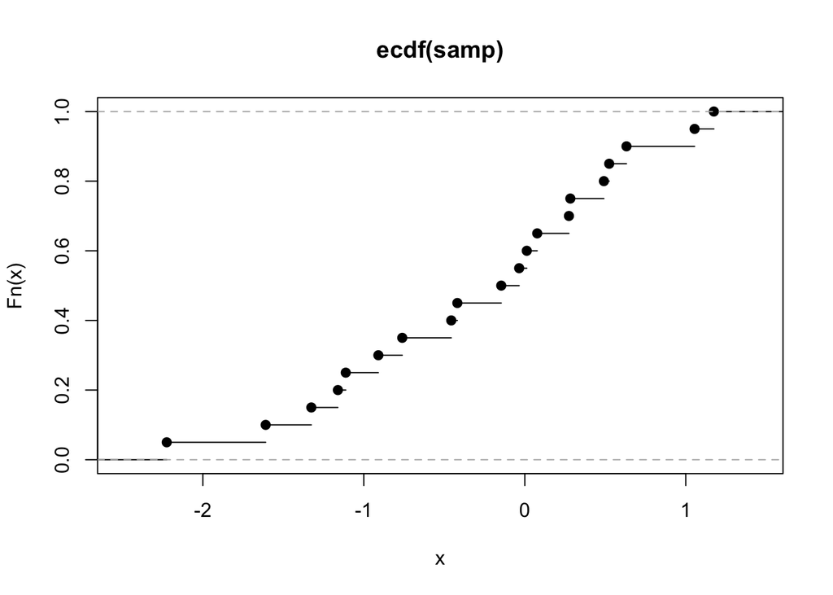

Empirical Cumulative Distribution Function - note the jumps at distinctive points along the x-axis.

```r
samp <- rnorm(20)
plot(ecdf(samp))
```

Confidence intervals are constructed similarly, using the ecdf, though it should be noted that estimating extreme quantiles poses difficulties because of the low density values in the area.

A first calculation to demonstrate this using replicate weights with the CA health interview study, estimating different quantiles of BMI.

```r
svyquantile(~bmi_p, design = chis, quantiles = c(0.25, 0.5, 0.75))
```

```
## $bmi_p
##      quantile ci.2.5 ci.97.5    se.97.5
## 0.25    22.68  22.66   22.81 0.03767982
## 0.5     25.75  25.69   25.80 0.02763161
## 0.75    29.18  29.12   29.29 0.04270393
##
## attr(,"hasci")
## [1] TRUE
## attr(,"class")
## [1] "newsvyquantile"
```

The same thing can be done with the stratified design. Here the uncertainty is computed via the estimates of the ecdf and finding the pointwise confidence interval for different points along the curve.

```r
svyquantile(~api00,
  design = strat_design, quantiles = c(0.25, 0.5, 0.75),
  ci = TRUE
)
```

```
## $api00
##      quantile ci.2.5 ci.97.5       se
## 0.25      565    535     597 15.71945
## 0.5       668    642     694 13.18406
## 0.75      756    726     778 13.18406
##
## attr(,"hasci")
## [1] TRUE
## attr(,"class")
## [1] "newsvyquantile"
```

You can see how to construct the same estimate below using the `srvyr` package.

```r
srvyr_strat_design %>%
  summarize(quantiles = survey_quantile(api00, quantiles = c(0.25, 0.5, 0.75)))
```

```
## # A tibble: 1 × 6
##   quantiles_q25 quantiles_q50 quantiles_q75 quantiles_q25_se quantiles_q50_se
##           <dbl>         <dbl>         <dbl>            <dbl>            <dbl>
## 1           565           668           756             15.7             13.2
## # ℹ 1 more variable: quantiles_q75_se <dbl>
```

### Contingency Tables

Lumley’s main points in this section focus on the complications in interpretation of typical contingency table tests of association in a design based setting. Specifically, he points out that it is not obvious how the null distribution should be generated without making some kind of modeling assumptions. Quoting from the book (text in parentheses from me):

> For example, if there are 56,181,887 women and 62,710,561 men in a population it is not possible for the proportions of men and women who are unemployed to be the same, since these population sizes have no common factors. We would know without collecting any employment data that the finite-population null hypothesis (of equal proportions) was false. A more interesting question is whether the finite population could have arisen from a process that had no association between the variables: is the difference at the population level small enough to have arisen by chance…. A simpler approach is to treat the sample as if it came from an infinite superpopulation and simply ignore the finite-population corrections in inference.

The super-population approach offers the more interesting approach philosophically and thus is implemented in the `survey` package. The `svychisq` function implements a test for no association as the null using a chi-squared distribution with a correction for the mean and variance. Lumley’s writing isn’t quite clear here, but it sounds like two methods for this approach are implemented but one is not used because of its performance in small samples, and takes a long time for very small p-values. This appears to be a case where one has to hope the default approach is generally appropriate.

Lumley demonstrates how to call these functions estimating smoking use by insurance status from the California Health Interview Survey.

```r
tab <- svymean(~ interaction(ins, smoking, drop = TRUE), chis)
tab
```

[output not shown]

```r
ftab <- ftable(tab, rownames = list(
  ins = c("Insured", "Uninsured"),
  smoking = c("Current", "Former", "Never")
))
```

### Estimates in Subpopulations

Estimation within subpopulations (also called domain estimation) that are sampled strata is easy since a stratified sample is composed of random samples within strata by definition; simply compute the desired statistic within the given strata using the strata-specific random sample.

When the subpopulation of interest is not a strata, things are more difficult. While the sampling weights would still be correct for representing any given observation to the total population — resulting in an unbiased mean point estimate — the co-occurrence probabilities $\pi_{i,j}$ would be incorrect, because the co-occurrence probabilities are now unknown/random and not fixed by design. Lumley doesn’t go into too much detail on how this addressed (even in the Appendix) but my reading is that he calculates the co-occurrence probabilities through a form of empirical distribution/replicate weighting. Examples below demonstrating this idea estimate the number of teachers with emergency, `emer`, training amongst California schools using the `api` dataset.

TODO(apeterson91): Add more on the ratio estimation technique used here to estimate subpopulation uncertainty.

```r
emerg_high <- subset(strat_design, emer > 20)
emerg_low <- subset(strat_design, emer == 0)
svymean(~ api00 + api99, emerg_high)
```

```
##         mean     SE
## api00 558.52 21.708
## api99 523.99 21.584
```

```r
svymean(~ api00 + api00, emerg_low)
```

```
##         mean     SE
## api00 749.09 17.516
```

```r
svytotal(~enroll, emerg_high)
```

```
##         total     SE
## enroll 762132 128674
```

```r
svytotal(~enroll, emerg_low)
```

```
##         total    SE
## enroll 461690 75813
```

In general, if replicate weights are available, domain estimation is much easier.

```r
bys <- svyby(~bmi_p, ~ srsex + racehpr, svymean, design = chis, keep.names = FALSE)
print(bys, digits = 3)
```

```
##     srsex                        racehpr bmi_p     se
## 1    MALE                         LATINO  28.2 0.1447
## 2  FEMALE                         LATINO  27.5 0.1443
## 3    MALE               PACIFIC ISLANDER  29.7 0.7055
## 4  FEMALE               PACIFIC ISLANDER  27.8 0.9746
## 5    MALE AMERICAN INDIAN/ALASKAN NATIVE  28.8 0.5461
## 6  FEMALE AMERICAN INDIAN/ALASKAN NATIVE  27.0 0.4212
## 7    MALE                          ASIAN  24.9 0.1406
## 8  FEMALE                          ASIAN  23.0 0.1112
## 9    MALE               AFRICAN AMERICAN  28.0 0.2663
## 10 FEMALE               AFRICAN AMERICAN  28.4 0.2417
## 11   MALE                          WHITE  27.0 0.0598
## 12 FEMALE                          WHITE  25.6 0.0680
## 13   MALE     OTHER SINGLE/MULTIPLE RACE  26.9 0.3742
## 14 FEMALE     OTHER SINGLE/MULTIPLE RACE  26.7 0.3158
```

```r
# This is the code from the book but it didn't work for me
# because of issues in the survey R package, I reproduce the
# first result using the srvyr package below
# medians <- svyby(~bmi_p, ~ srsex + racehpr, svyquantile,
#   design = chis,
#   covmat = TRUE,
#   quantiles = 0.5
# )
# svycontrast(medians, quote(MALE.LATINO/FEMALE.LATINO))

medians <- chis %>%
  as_survey() %>%
  group_by(srsex, racehpr) %>%
  summarize(Median_BMI = survey_median(bmi_p, vartype = "ci"))

medians
```

```
## # A tibble: 14 × 5
## # Groups:   srsex [2]
##    srsex  racehpr                       Median_BMI Median_BMI_low Median_BMI_upp
##    <fct>  <fct>                              <dbl>          <dbl>          <dbl>
##  1 MALE   LATINO                              27.4           27.3           27.8
##  2 MALE   PACIFIC ISLANDER                    28.9           27.8           30.7
##  3 MALE   AMERICAN INDIAN/ALASKAN NATI…       28.4           26.9           29.3
##  4 MALE   ASIAN                               24.4           24.2           24.8
##  5 MALE   AFRICAN AMERICAN                    27.4           26.6           28.1
##  6 MALE   WHITE                               26.4           26.3           26.5
##  7 MALE   OTHER SINGLE/MULTIPLE RACE          26.6           25.9           27.5
##  8 FEMALE LATINO                              26.3           25.8           26.5
##  9 FEMALE PACIFIC ISLANDER                    27.3           25.6           28.3
## 10 FEMALE AMERICAN INDIAN/ALASKAN NATI…       25.1           24.5           26.5
## 11 FEMALE ASIAN                               22.1           22.0           22.4
## 12 FEMALE AFRICAN AMERICAN                    27.2           26.6           27.5
## 13 FEMALE WHITE                               24.3           24.2           24.4
## 14 FEMALE OTHER SINGLE/MULTIPLE RACE          25.7           25.1           26.5
```

## Design of Stratified Samples

How to pick the sample size for each strata? Well it depends on the goals of the analysis. If the goal is to estimate a total across the whole population, the formula for the variance of a total can be used to gain insights about optimal allocation. Since the variance of the total is dependent (via sum) of the strata specific variances, more sample size would want to be dedicated to more heterogeneous and/or larger strata.

This general approach means that the sample size for strata $k$, $n_k$ should be proportional to the population strata size $N_k$ and strata variance $\sigma^{2}_k$, $n_k \propto \sqrt{N^2_k \sigma^2_k} = N_k \sigma_k$. Lumley notes that while this expression satisfies some theoretical optimality criteria, it is often the case that different strata have different costs associated with their sampling and so the expression can be modified in order to take into account this cost as follows:

$$n_k \propto \frac{ N_k \sigma_k}{\sqrt{\text{cost}_k}},$$

where cost$_k$ is the cost of sampling for strata $k$.

### Demo: Stratified Samples

From our previous example, using the `school_data` we can estimate a stratified sample by using `slice_sample()` again but putting a `group_by()` statement beforehand to specify the strata, or groups within which we’d like a sample.

```r
school_data %>%
  group_by(class_id) %>%
  slice_sample(n = 5) %>%
  as_survey_design(strata = class_id) %>%
  summarize(
    mean_height = survey_mean(height, vartype = "ci")
  )
```

```
## # A tibble: 1 × 3
##   mean_height mean_height_low mean_height_upp
##         <dbl>           <dbl>           <dbl>
## 1        38.3            37.6            39.0
```

Note the increased precision compared to our prior estimate. The increased precision comes from the strata information.

## Questions

1.You are conducting a survey of emergency preparedness at a large HMO, where you want to estimate what proportion of medical staff would be able to get to work after an earthquake.

a.) You can either send out a single questionnaire to all staff, or send out a questionnaire to about 10% of the staff and make follow-up phone calls for those that don’t respond. What are the disadvantages of each approach?

This comes down to a discussion of cost for sampling and what missing data mechanism may be at play. As a simple starting point, if we were to assume the resulting data were MCAR and the non response rate was equivalent between both sampling strategies, the single questionnaire would be preferred because it would result in a higher overall sample size. These assumptions are probably not likely however, and we may expect that non-response is associated with other meaningful factors, by choosing a the follow-up phone call we might minimize non-response to both reduce bias and improve precision.

Additional relevant concerns would be the possible response or lack of response of certain strata — certain physicians, technicians or other kinds of staff’s response would likely be worth knowing yet these groups may be less well represented in a 10% simple random sample of the population.

b.) You choose to survey just a sample. What would be useful variables to stratify the sampling, and why?

The aforementioned job title would be useful to stratify on. This would likely be most useful to conduct within each department. Further, if the HMO has more than one site or clinic, that would be worth stratifying on as well for substantive reasons just as much as statistical reasons.

c.) The survey was conducted with just two strata: physicians and other staff. The HMO has 900 physicians and 9000 other staff. You sample 450 physicians and 450 other staff. What are the sampling probabilities in each stratum?

physician strata sampling probabilities are $\frac{n}{N_k} = \frac{450}{900} = \frac{1}{2}$, while the “other staff” probabilities are $\frac{450}{9000} = \frac{1}{20}$

d.) 300 physicians and 150 other staff say they would be able to get to work after an earthquake. Give unbiased estimates of the proportion in each stratum and the total proportion.

The physician strata estimate would be $\frac{300}{450} = \frac{2}{3}$. The staff strata would be $\frac{150}{450} = \frac{1}{3}$ The total proportion would be $\frac{2 \times 300 + 20 \times 150}{9900}$. This value can be recreated below with the `survey` package as follows.

```r
df <- tibble(
  id = 1:900,
  job = c(rep("MD", 450), rep("staff", 450)),
  prep = c(rep(1, 300), rep(0, 150), rep(1, 150), rep(0, 300)),
  weights = c(rep(2, 450), rep(20, 450))
)
hmo_design <- svydesign(strata = ~job, ids = ~0, weights = ~weights, data = df)
hmo_design
```

```
## Stratified Independent Sampling design (with replacement)
## svydesign(strata = ~job, ids = ~0, weights = ~weights, data = df)
```

```r
svymean(~prep, hmo_design)
```

```
##         mean     SE
## prep 0.36364 0.0203
```

e.) How would you explain to the managers that commissioned the study how the estimate was computed and why it wasn’t just the number who said “yes” divided by the total number surveyed?

We sampled from the total population using the strata because we though these two groups would respond differently and indeed, they did. Physicians have are twice as likely to be able to make it to the hospital in the event of an emergency as general staff. However, physicians make up a much smaller proportion of the overall hospital workforce and so we need to downweight their responses, relative to general staff in order to ensure their response reflects their distribution in the total population, thus the total estimate of the HMO’s emergency preparedness is much closer to the “general” staff’s strata estimate of $\frac{1}{3}$.

2.You are conducting a survey of commuting time and means of transport for a large university. What variables are likely to be available and useful for stratifying the sampling?

Probably worth stratifying on “role” at university — student vs. staff vs. professor. Each of these have varying amounts of income available and would likely determine their different means and, consequently, commute time of getting to campus. It might also be worth stratifying on the department of employment for staff and professors, as there can be a wide variability in these measures, again, by department.

3.-4. Skip because of CHIS data issues

5. In the Academic Performance Index data we saw large gains in precision from stratification on school type when estimating mean or total school size, and no gain when estimating mean Academic performance Index. Would you expect a large or small gain from the following variables: `mobility`, `emer`, `meals`, `pcttest`? Compare your expectations with the actual results.

The general principle here, is which of these variables do we expect to have some association with the school type. The greater association the more the benefit from stratifying.

# Chapter 3: Cluster Sampling

## Why Clusters? The NHANES design

Why sample clusters? Because sometimes it’s easier than sampling individuals. Specifically, in cases where the *cost* of sampling individuals can be quite high, sampling clusters can be more efficient. This is in spite of the fact that within cluster correlation tends to be positive, reducing the information in the sample. Lumley uses the NHANES survey to motivate this idea: moving mobile examination centers all across the country to sample individuals is extremely expensive. By sampling a large number of individuals within a census tract aggregation area the NHANES survey is able to reduce the cost of their effort at a reasonable expense in precision.

### Single-stage and multistage designs

Depending on the type of clusters involved it can be easy to sample the entire cluster as classrooms, medical practice and workplaces are, however it is more likely that some subsampling within clusters will be performed for the sake of efficiency. As Lumley notes, clusters in the first stage are called *Primary Sampling Units* or PSUs. “Stages” refer to the different levels at which sampling occurs. E.g. Sampling individuals within sampled census tracts within a state would involve sampling census tracts in the first stage and then individuals in the second stage. The diagram below communicates this idea graphically.

[interactive chart not shown]

Sampling weights are determined assuming independence across stages — e.g. if a cluster of houses is sampled with probability $\pi_1$ and a household is sampled within that cluster with probability $\pi_2$ then the sampling probability for that house is $\pi = \pi_1 \times \pi_2$ and it’s weight is the inverse of that probability. Note that this requires that clusters be mutually exclusive - a sampled unit can belong only to one cluster and no others. Further, note that we can still have biased sampling *within* a stage, as independence is only required across stages to use to find probabilities via their product.

Lumley goes on to describe how cluster sampling and individual sampling can be mixed since each stratum of a survey can be thought of as a separate and independent sample it is trivial to combine single stage sampling in one stratum and multistage sampling in another; a stratified random sample can be used in high density regions where measurement of multiple units is less costly and a cluster sample can be taken in low density regions where the cost of each additional unit is more costly.

The statistical rationale behind this strategy is fairly straightforward — since the variance of the sum is the sum of the variances of each stage (assuming independence) each sampled cluster in a multistage sample can be considered as a population for further sampling. Lumley uses the example of a simplified NHANES design, where 64 regions are grouped into 32 strata. A simple random sample of 440 individuals are then measured in each region. In Lumley’s words,

> The variance of an estimated total from this design can be partitioned across two sources: the variance of each estimated regional total around the true total of the region and the variance that would result if the true total for each of the 64 sampled regions were known exactly.

In my own words and understanding, I understand there to be variance that comes from grouping the 64 regions into 32 strata — so there is uncertainty across region and then the uncertainty within that region that results from the sample of *only* a subset of the population.

## Describing Multi Stage Designs to R

In order to specify a single stage cluster sample or a multistage sample treated as a single stage sample with replacement, the main difference is that the PSU identifier needs to be supplied to the `id` argument, as follows.

```r
# Data originally found at
# "https://github.com/cran/LogisticDx/blob/master/data/nhanes3.rda"
```

```r
names3 <- load("Data/nhanes/nhanes3.rda")
as_tibble(nhanes3)
```

```
## # A tibble: 17,030 × 16
##     SEQN SDPPSU6 SDPSTRA6 WTPFHX6 HSAGEIR HSSEX  DMARACER BMPWTLBS BMPHTIN
##    <dbl>   <dbl>    <dbl>   <dbl>   <dbl> <fct>  <fct>       <dbl>   <dbl>
##  1     3       1       44   1735.      21 male   white        180.    70.4
##  2     4       1       43   1725.      32 female white        136.    63.9
##  3     9       2       43  19452.      48 female white        150.    61.8
##  4    10       1        6  27770.      35 male   white        204.    69.8
##  5    11       2       40   1246.      48 male   white        155.    66.2
##  6    19       1       35   3861.      44 male   black        190.    70.2
##  7    34       1       13   5032.      42 female black        126.    62.6
##  8    44       1        8  28149.      24 female white        123.    64.4
##  9    45       1       22   4582.      67 female black        150.    64.3
## 10    48       1       24  26919.      56 female white        240.    67.6
## # ℹ 17,020 more rows
## # ℹ 7 more variables: PEPMNK1R <dbl>, PEPMNK5R <dbl>, HAR1 <fct>, HAR3 <fct>,
## #   SMOKE <fct>, TCP <dbl>, HBP <fct>
```

```r
svydesign(
  id = ~SDPPSU6, strat = ~SDPSTRA6,
  weight = ~WTPFHX6,
  ## nest = TRUE indicates the PSU identifier is nested
  ## within stratum - repeated across strata
  nest = TRUE,
  data = nhanes3
)
```

```
## Stratified 1 - level Cluster Sampling design (with replacement)
## With (98) clusters.
## svydesign(id = ~SDPPSU6, strat = ~SDPSTRA6, weight = ~WTPFHX6,
##     nest = TRUE, data = nhanes3)
```

SDPPSU6 is the pseudo PSU variable, and SDPSTRA6 is the stratum identifier defined for the single stage analysis.

For example, a two stage design for the API population that samples 40 school districts, then five schools within each district , the design has population size 757 at the first stage for the number of school districts in CA and the number of schools within each district for the second stage. The weights need not be supplied if they can be worked out from the other arguments.

```r
data(api)
as_tibble(apiclus2)
```

```
## # A tibble: 126 × 40
##    cds       stype name  sname  snum dname  dnum cname  cnum  flag pcttest api00
##    <chr>     <fct> <chr> <chr> <dbl> <chr> <int> <chr> <int> <int>   <int> <int>
##  1 31667796… E     Alta… Alta…  3269 Alta…    15 Plac…    30    NA     100   821
##  2 55751846… E     Tena… Tena…  5979 Big …    63 Tuol…    54    NA     100   773
##  3 41688746… E     Pano… Pano…  4958 Bris…    83 San …    40    NA      98   600
##  4 41688746… M     Lipm… Lipm…  4957 Bris…    83 San …    40    NA     100   740
##  5 41688746… E     Bris… Bris…  4956 Bris…    83 San …    40    NA      98   716
##  6 40687266… E     Cayu… Cayu…  4915 Cayu…   117 San …    39    NA     100   811
##  7 20651936… E     Full… Full…  2548 Chow…   132 Made…    19    NA     100   472
##  8 20651936… E     Fair… Fair…  2550 Chow…   132 Made…    19    NA     100   520
##  9 20651936… M     Wils… Wils…  2549 Chow…   132 Made…    19    NA     100   568
## 10 06615980… H     Colu… Colu…   348 Colu…   152 Colu…     5    NA      96   591
## # ℹ 116 more rows
## # ℹ 28 more variables: api99 <int>, target <int>, growth <int>, sch.wide <fct>,
## #   comp.imp <fct>, both <fct>, awards <fct>, meals <int>, ell <int>,
## #   yr.rnd <fct>, mobility <int>, acs.k3 <int>, acs.46 <int>, acs.core <int>,
## #   pct.resp <int>, not.hsg <int>, hsg <int>, some.col <int>, col.grad <int>,
## #   grad.sch <int>, avg.ed <dbl>, full <int>, emer <int>, enroll <int>,
## #   api.stu <int>, pw <dbl>, fpc1 <dbl>, fpc2 <int[1d]>
```

```r
## dnum = district id
## snum = school id
## fpc1 = school id number
clus1_design <- svydesign(id = ~dnum, fpc = ~fpc, data = apiclus1)
clus2_design <- svydesign(id = ~ dnum + snum, fpc = ~ fpc1 + fpc2, data = apiclus2)
clus2_design
```

```
## 2 - level Cluster Sampling design
## With (40, 126) clusters.
## svydesign(id = ~dnum + snum, fpc = ~fpc1 + fpc2, data = apiclus2)
```

## Strata with only one PSU

When only one PSU exists within a population stratum, the sampling fraction *must* be 100%, since otherwise it would be 0%. In this case, the stratum does not contribute to the first stage variance and it should be ignored in calculating the first stage variance. Lumley argues that the best way to handle a stratum with only one PSU is to combine it with another stratum, one that is chosen to be similar based on *population* data available before the study was done. The `survey` package has two different methods implemented to handle “lonely” PSU’s. Lumley has written further on this topic [here](http://r-survey.r-forge.r-project.org/survey/exmample-lonely.html).

## How good is the single-stage approximation?

Here Lumley walks through an example detailing the trade-offs involved in using the single stage approximation. I’ll try to come up with a simulated example later as the data is not listed on the book’s [website](https://r-survey.r-forge.r-project.org/svybook/) nor is it clear how to reassemble his dataset from the files at the [NHIS site](https://ftp.cdc.gov/pub/Health_Statistics/NCHS/Datasets/NHIS/1992/).

## Sampling by Size

> Why do white sheep eat more than black sheep? There are more white sheep than black sheep

A specific design theory, *Probability-proportional-to-size* (PPS), cluster sampling is a sampling strategy that exploits the fact that for a simple random sample of an unstratified population $\pi_i$ can be chosen such that it is approximately proportional to $X_i$, the variable of interest, the variance of the estimate of the total $V[\hat{T}] = \frac{N-n}{N} N^{2} \frac{V[X]}{n}$ can be controlled to be quite small. (Tillé 2006; Hanif and Brewer 1980) discuss these ideas further.

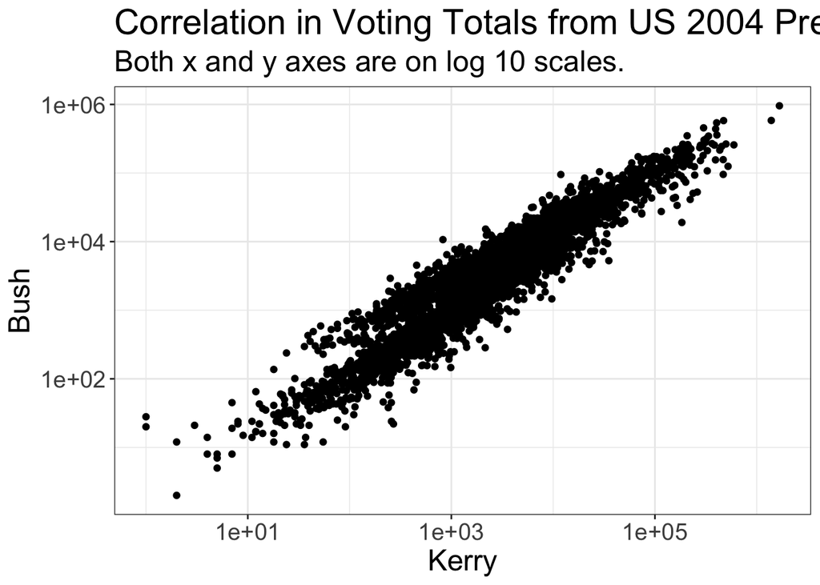

```r
data(election)
election <- as_tibble(election) %>%
  mutate(
    votes = Bush + Kerry + Nader,
    p = 40 * votes / sum(votes)
  )
election %>%
  ggplot(aes(x = Kerry, y = Bush)) +
  geom_point() +
  scale_y_log10() +
  scale_x_log10() +
  ggtitle("Correlation in Voting Totals from US 2004 Presidential Election",
    subtitle = "Both x and y axes are on log 10 scales."
  )
```

When Lumley’s book was written, only the single stage approximation of PPS could be analyzed using the `survey` package. A demo is shown below using the voting data, where a PPS sample is constructed and then analyzed.

```r
data(election)
election <- as_tibble(election) %>%
  mutate(
    votes = Bush + Kerry + Nader,
    p = 40 * votes / sum(votes)
  )
election
```

```
## # A tibble: 4,600 × 8
##    County   TotPrecincts PrecinctsReporting   Bush Kerry Nader  votes       p
##    <fct>           <int>              <int>  <int> <int> <int>  <int>   <dbl>
##  1 Alaska            439                439 151876 86064  3890 241830 0.0832
##  2 Autauga            22                 22  15212  4774    74  20060 0.00691
##  3 Baldwin            50                 50  52910 15579   371  68860 0.0237
##  4 Barbour            24                 24   5893  4826    26  10745 0.00370
##  5 Bibb               16                 16   5471  2089    12   7572 0.00261
##  6 Blount             26                 26  17364  3932    92  21388 0.00736
##  7 Bullock            27                 27   1494  3210     3   4707 0.00162
##  8 Butler             27                 27   4978  3409    13   8400 0.00289
##  9 Calhoun            53                 53  29806 15076   182  45064 0.0155
## 10 Chambers           24                 24   7618  5346    42  13006 0.00448
## # ℹ 4,590 more rows
```

```r
library(sampling)
insample <- UPtille(election$p)
ppsample <- election[insample == 1, ]
ppsample$wt <- 1 / ppsample$p
pps_design <- svydesign(id = ~1, weight = ~wt, data = ppsample)
pps_design
```

```
## Independent Sampling design (with replacement)
## svydesign(id = ~1, weight = ~wt, data = ppsample)
```

```r
svytotal(~ Bush + Kerry + Nader, pps_design, deff = TRUE)
```

```
##          total       SE   DEff
## Bush  57439625  2433599 0.0157
## Kerry 58398753  2426480 0.0087
## Nader   360726    92269 0.3648
```

## Loss of information from sampling clusters

The loss of precision per observation from cluster sampling is given by the design effect.

> “For a single-stage cluster sample with all clusters having the same number of individuals, $m$, the design effect is

$$DEff = 1 + (m-1)\rho,$$

> where $\rho$ is the within-cluster correlation.

Lumley illustrates how design effects can illustrate the impact on inference using the California school data set from before as well as the Behavioral Risk Factor Surveillance System from 2007.

```r
svymean(~ api00 + meals + ell + enroll, clus1_design, deff = TRUE)
```

```
##            mean       SE    DEff
## api00  644.1694  23.5422  9.2531
## meals   50.5355   6.2690 10.3479
## ell     27.6120   2.0193  2.6711
## enroll 549.7158  45.1914  2.7949
```

In the above, the variance is up to 10 times higher in the cluster sample as compared to a simple random sample.

```r
## Lumley renames clus2_design to dclus2 from before. I maintain the same names.
svymean(~ api00 + meals + ell + enroll, clus2_design, deff = TRUE, na.rm = TRUE)
```

```
##            mean       SE    DEff
## api00  673.0943  31.0574  6.2833
## meals   52.1547  10.8368 11.8585
## ell     26.0128   5.9533  9.4751
## enroll 526.2626  80.3410  6.1427
```

Similarly, when computing the proportion of individuals who have more than 5 servings of fruits and vegetables a day (X_FV5SRV = 2), as well as how often individuals received a cholesterol test in the past 5 years (X_CHOLCHK = 1) from the 2007 Behavioral Risk Factor Surveillance System dataset, we see design effects that reflect the geographic variability across the blocks of telephone numbers that were sampled for the survey.

```r
brfss <- svydesign(
  id = ~X_PSU, strata = ~X_STATE, weight = ~X_FINALWT,
  data = "brfss", dbtype = "SQLite",
  dbname = "data/BRFSS/brfss07.db", nest = TRUE
)
brfss
```

```
## DB-backed Stratified Independent Sampling design (with replacement)
## svydesign(id = ~X_PSU, strata = ~X_STATE, weight = ~X_FINALWT,
##     data = "brfss", dbtype = "SQLite", dbname = "data/BRFSS/brfss07.db",
##     nest = TRUE)
```

```r
food_labels <- c("Yes Veg", "No Veg")
chol_labels <- c("within 5 years", ">5 years", "never")
svymean(~ factor(X_FV5SRV) +
  factor(X_CHOLCHK),
brfss,
deff = TRUE
)
```

```
##                          mean         SE   DEff
## factor(X_FV5SRV)1  0.73096960 0.00153359 5.1632
## factor(X_FV5SRV)2  0.23844253 0.00145234 5.0147
## factor(X_FV5SRV)9  0.03058787 0.00069991 7.1323
## factor(X_CHOLCHK)1 0.73870300 0.00168562 6.3550
## factor(X_CHOLCHK)2 0.03230828 0.00058759 4.7676
## factor(X_CHOLCHK)3 0.19989559 0.00162088 7.0918
## factor(X_CHOLCHK)9 0.02909313 0.00055471 4.7029
```

## Repeated Measurements

Lumley notes that design based inference continues to differ from model based in its analysis of repeated measurements. Where model based inference is careful to account for modeling the – for example – within person or within household correlation in a cohort study, no such adjustment is required in a designed survey other than adjusting and using the appropriate weights - treating the repeated measurement like another stage of clustering in the sampling.

Lumley illustrates this with the Survey of Income and Program Participation (SIPP) panel survey.

> Each panel is followed for multiple years, with subsets of the panel participating in four month waves of follow-up… wave 1 of the 1996 panel, which followed 36,730 households with interviews every four months, starting in late 1995 or early 1996… The households were recruited in a two-stage sample. The first stage sampled 322 counties or groups of counties as PSUs; the second stage sampled households within these PSUs.

```r
sipp_hh <- svydesign(
  id = ~ghlfsam, strata = ~gvarstr, nest = TRUE,
  weight = ~whfnwgt, data = "household", dbtype = "SQLite", dbname = "Data/SIPP/sipp.db"
)
sipp_hh <- update(sipp_hh,
  month = factor(rhcalmn,
    levels = c(12, 1, 2, 3, 4, 5, 6),
    labels = c(
      "Dec", "Jan", "Feb", "Mar",
      "Apr", "May", "Jun"
    )
  )
)
qinc <- svyby(~thtotinc, ~month, svyquantile,
  design = sipp_hh,
  quantiles = c(0.25, 0.5, 0.75, 0.9, 0.95), se = TRUE
)
pltdf <- as_tibble(qinc) %>%
  select(month, contains("thtotinc"), -contains("se")) %>%
  gather(everything(), -month, key = "quantile", value = "Total Income") %>%
  mutate(quantile = as.numeric(str_extract(quantile, "[0-9].[0-9]?[0-9]")) * 100)

se <- as_tibble(qinc) %>%
  select(month, contains("se")) %>%
  gather(everything(), -month, key = "quantile", value = "SE") %>%
  mutate(quantile = as.numeric(str_extract(quantile, "[0-9].[0-9]?[0-9]")) * 100)

pltdf <- pltdf %>%
  left_join(se) %>%
  mutate(
    lower = `Total Income` - 2 * SE,
    upper = `Total Income` + 2 * SE
  )
```

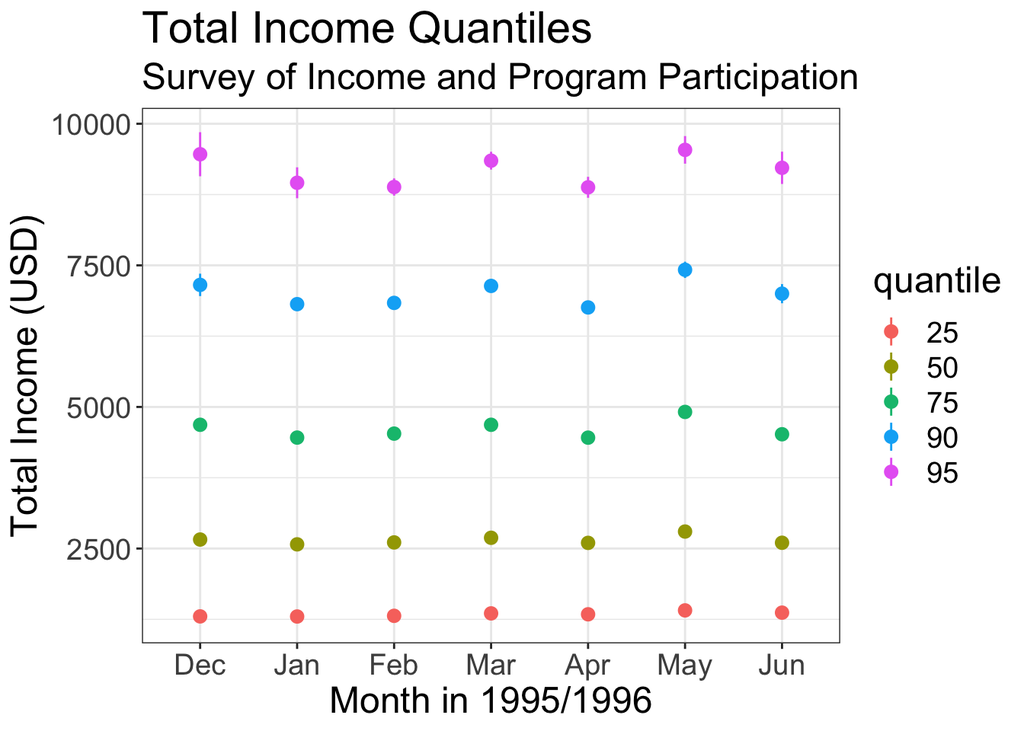

```r
pltdf %>%
  mutate(quantile = factor(quantile)) %>%
  ggplot(aes(x = month, y = `Total Income`, color = quantile)) +
  geom_pointrange(aes(ymin = lower, ymax = upper)) +
  xlab("Month in 1995/1996") +
  ylab("Total Income (USD)") +
  ggtitle("Total Income Quantiles",
          subtitle ="Survey of Income and Program Participation")
```

## Questions

1. The web site has data files demo_x.xpt of demographic data and bpx_c.xpt of blood pressure data from NHANES 2003-2004. Code to load and merge these data sets is in Appendix B, in Figure B.1
1. Construct a survey design object with these data.

```r
## data are from the book website:
# https://r-survey.r-forge.r-project.org/svybook/
# demographic data
ddf <- haven::read_xpt("data/nhanesxpt/demo_c.xpt")
# blood pressure data
bpdf <- haven::read_xpt("data/nhanesxpt/bpx_c.xpt")
```

2. Estimate the proportion of the US population with systolic blood pressure over 140 mm HG

# Chapter 4: Graphics

Lumley advocates for three principles in visualizing survey data:

1. Base the graph on an estimated population distribution.
2. Explicitly indicate weights on the graph.
3. Draw a simple random sample from the estimated population distribution and graph this sample instead.

All three of these strategies are meant to counteract the difficulty in visualizing survey data — the data available do not represent the population of interest without re-weighting.

While these principles are great and worth following, I found Lumley’s demonstrations in this chapter a little out of date. Thanks to the [ggplot](https://ggplot2.tidyverse.org/) family of libraries and [shiny](https://www.rstudio.com/products/shiny/) there’s been huge advances in visualizing and interacting with data of all types – survey included. What’s more, it isn’t always clear how he produces the charts in the chapter. Consequently I’ve done my best to reproduce the same charts, or a chart I’d consider appropriate for the question / survey at hand in the following charts.

## Plotting a Table

Lumley recommends using bar charts, forest plots and fourfold plots to visualize the data from a table. I would agree that all of these are “fine” in a certain context but strongly prefer the forest plot and variations on it personally, since it does more than all the other to include representations of uncertainty about the tabulated estimates.

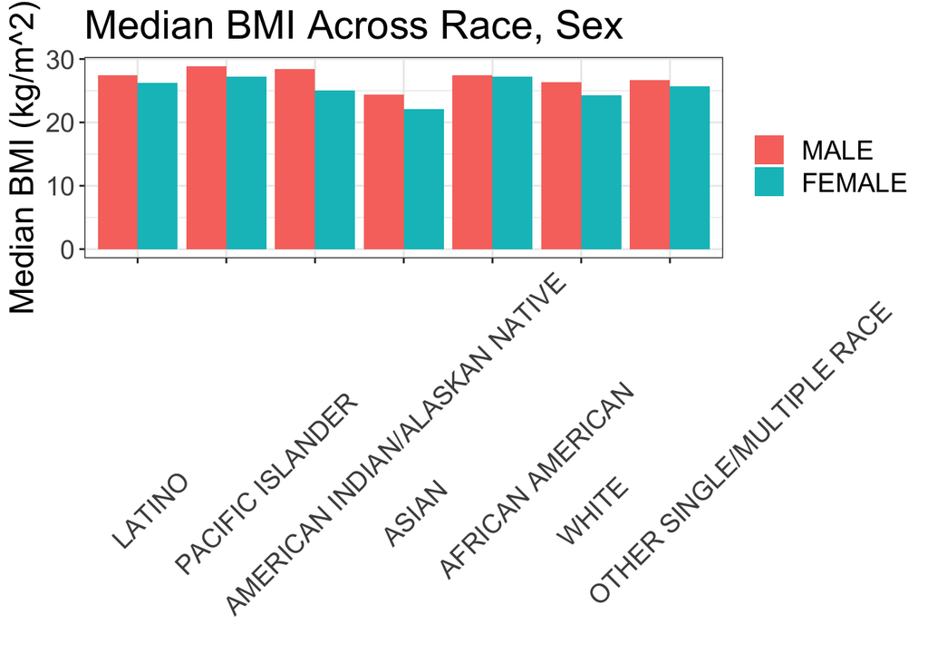

```r
medians %>%
  ggplot(aes(x = racehpr, y = Median_BMI, fill = srsex)) +
  geom_bar(stat = "identity", position = "dodge") +
  ylab("Median BMI (kg/m^2)") +
  xlab("") +
  theme(
    legend.title = element_blank(),
    axis.text.x = element_text(angle = 45, vjust = 0.25, hjust = .25)
  ) +
  ggtitle("Median BMI Across Race, Sex")
```

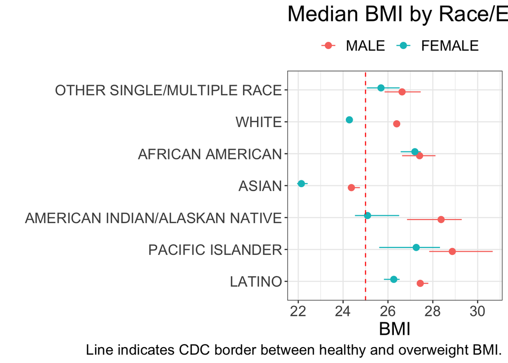

```r
medians %>%
  ggplot(aes(x = Median_BMI, y = racehpr, color = srsex)) +
  geom_pointrange(aes(xmin = Median_BMI_low, xmax = Median_BMI_upp),
    position = position_dodge(width = .25)
  ) +
  geom_vline(aes(xintercept = 25), linetype = 2, color = "red") +
  xlab("BMI") +
  ylab("") +
  theme(legend.title = element_blank(), legend.position = "top") +
  ggtitle("Median BMI by Race/Ethnicity and gender, from CHIS") +
  labs(caption = str_c(
    "Line indicates CDC border between healthy and ",
    "overweight BMI."
  ))
```

# Chapter 5: Ratios and Linear Regression

Lumley identifies two main uses for regression in analyzing complex surveys:

1. Identifying relationships between variables — similar to any other data.
2. More accurate estimates of population means and totals.

# Chapter 6: Categorical Data Regression

# Chapter 7: Post-Stratification, Raking, and Calibration

## Introduction - Motivation

Lumley motivates the need to explore the three titular topics by expanding on the principle developed in the second chapter — stratification. Similar as to how making use of the extra information available in strata we can improve estimates in straightforward estimation of totals and means, Lumley’s focus in this chapter is how to use the “auxiliary” information to adjust for non-response bias and improve the precision of the estimates.

## Post-Stratification

Post-stratification is exactly what it sounds like - re-weighting estimates according to strata totals *after* or apart from any initial strata that might have been involved in the inital sampling design.

Consider a relatively straightforward design in which there’s a population of subjects of size $N$ that can be partitioned into $K$ mutually exclusive strata from which any of the $N_k$ individuals in that strata can be sampled for $n_k$ strata samples. In this setting the sampling weights for each individual in group $k$ is $\frac{N_k}{n_k}$ and $N_k$ is known without any uncertainty.

If the sampling were not stratified but $N_k$ were still known, the group sizes would not be exactly correct by simple Horvitz-Thompson estimation, but they could be corrected by re-weighting so that the sizes are correct as they would be in stratified sampling.

Specifically, take each weight $w_i = \frac{1}{\pi_i}$ and construct new weights $w_i^* = \frac{g_i}{\pi_i} = \frac{N_k}{\hat{N}_k} \times \frac{1}{\pi_i}$.

For estimating the group side of the kth group then, we’ll have

$$n_k \times \frac{g_i}{\pi_i} = n_k \times \frac{1}{\pi_i} \times
\frac{N_k}{\hat{N}_k} = n_k \times \frac{\hat{N}_k}{n_k} \times
\frac{N_k}{\hat{N}_k} = N_k,$$
where $\pi_i = \frac{n_k}{\hat{N}_k}$. The consequence of this re-weighting means that the estimated sub group population is exactly correct and subsequent estimates within or across these groups benefit from the extra information.

Of course, as Lumley notes, there’s a problem if no entities were sampled in the particular strata of interest - you can’t re-weight the number 0. Still since this is unlikely to happen for groups and samples of “reasonable” size post-stratification is still a worthy strategy given the potential reductions in variance that are possible.

### Illustration

Lumley’s illustration of post-stratification looks at the two-stage sample drawn from the API population, with 40 school districts sampled from California and then up to 5 schools sampled from each district. Lumley uses this example to illustrate how improvements to precision can be made via post-stratification – or not.

We’ll start with a reminder of the sample design used here: a two-stage sample.

```r
clus2_design
```

```
## 2 - level Cluster Sampling design
## With (40, 126) clusters.
## svydesign(id = ~dnum + snum, fpc = ~fpc1 + fpc2, data = apiclus2)
```

Then information about the population group sizes is included in the call to `postStratify()` as well as the variable/strata across which to post-stratify.

```r
pop.types <- data.frame(stype = c("E", "H", "M"), Freq = c(4421, 755, 1018))
ps_design <- postStratify(clus2_design, strata = ~stype, population = pop.types)
ps_design
```

```
## 2 - level Cluster Sampling design
## With (40, 126) clusters.
## postStratify(clus2_design, strata = ~stype, population = pop.types)
```

```r
svytotal(~enroll, clus2_design, na.rm = TRUE)
```

```
##          total     SE
## enroll 2639273 799638
```

```r
svytotal(~enroll, ps_design, na.rm = TRUE)
```

```
##          total     SE
## enroll 3074076 292584
```

In contrast, school type is not associated with the variability in the school scores measured by the Academic Performance Index - denoted below by `api00`.

```r
svymean(~api00, clus2_design)
```

```
##         mean     SE
## api00 670.81 30.099
```

```r
svymean(~api00, ps_design)
```

```
##       mean     SE
## api00  673 28.832
```

Indeed, the score is specifically setup to be standardized across school types and as such there’s little variance reduction observed by using the post-stratification information in this instance.

Lumley notes that if the api dataset were a real survey, non response might vary as a function of school type and in which case post-stratification could help reduce non-response bias.

# Chapter 8: Two-Phase Sampling

# Chapter 9: Missing Data

# Chapter 10: Causal Inference

# References

Hanif, Muhammad, and KRW Brewer. 1980. “Sampling with Unequal Probabilities Without Replacement: A Review.” *International Statistical Review/Revue Internationale de Statistique*, 317–35.

Judkins, David R. 1990. “Fay’s Method for Variance Estimation.” *Journal of Official Statistics* 6 (3): 223–39.

Kish, Leslie. 1965. *Survey Sampling*. New York: Chichester Wiley.

Lumley, Thomas. 2011. *Complex Surveys: A Guide to Analysis Using r*. Vol. 565. John Wiley & Sons.

McCarthy, Philip J. 1966. “Replication, an Approach to the Analysis of Data from Complex Surveys.”

Meng, Xiao-Li. 2018. “STATISTICAL PARADISES AND PARADOXES IN BIG DATA (i) LAW OF LARGE POPULATIONS, BIG DATA PARADOX, AND THE 2016 US PRESIDENTIAL ELECTION.” *The Annals of Applied Statistics* 12 (2): 685–726.

Tillé, Yves. 2006. *Sampling Algorithms*. Springer.